# network analysis HW6

Yang

4/12/2021

# network analysis HW6

r09228001 臺大地理所碩一 楊宇翔 2021/4/12 (Mon.)

利用m128班級成員的三種關係：friendship, social and task，分別以R igraph and Gephi 進行繪圖與計算網絡指標，包括：centrality and subgroups；並就指標分析結果，討論在這三種關係的成員重疊性與成員的網絡連結特性。

```r
#install.packages("NetData")
rm(list=ls(all=TRUE))
library(igraph)
library(NetData)
```

# 1. 繪圖

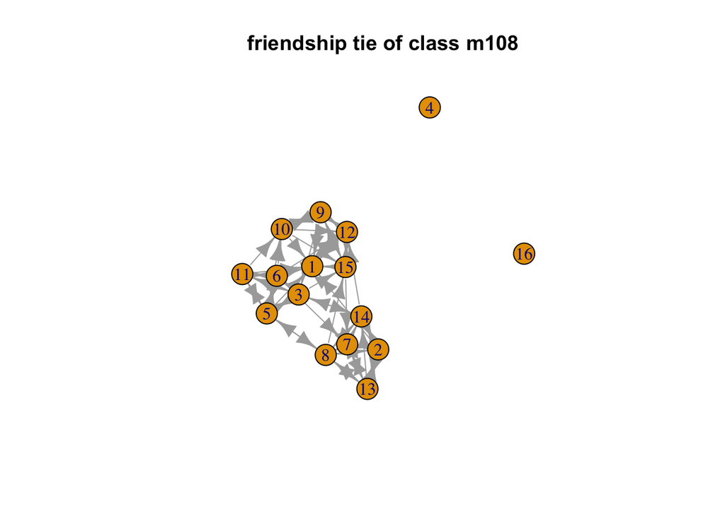

```r
data(studentnets.M182, package = "NetData")

nodes=c(1:16)
edges=m182_full_data_frame

f=edges[which(edges[,3]!=0),]
s=edges[which(edges[,4]!=0),]
t=edges[which(edges[,5]!=0),]

g1 = graph.data.frame (f, directed=T, nodes)
plot(g1, main="friendship tie of class m108")
```

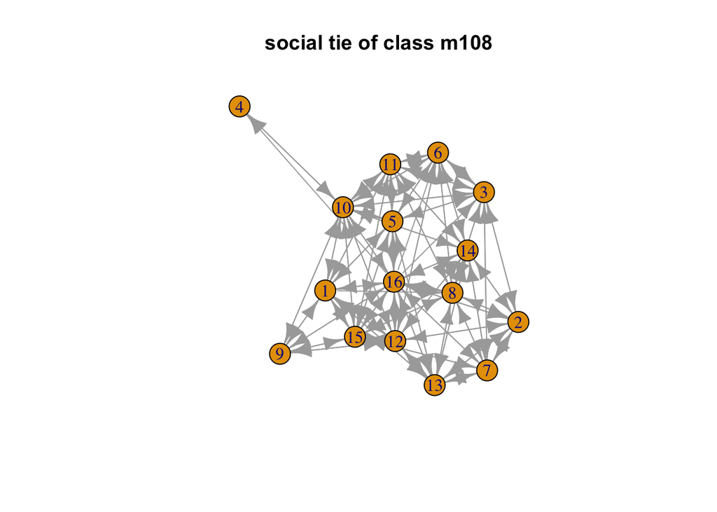

```r
g2 = graph.data.frame (s, directed=T, nodes)
plot(g2, main="social tie of class m108")
```

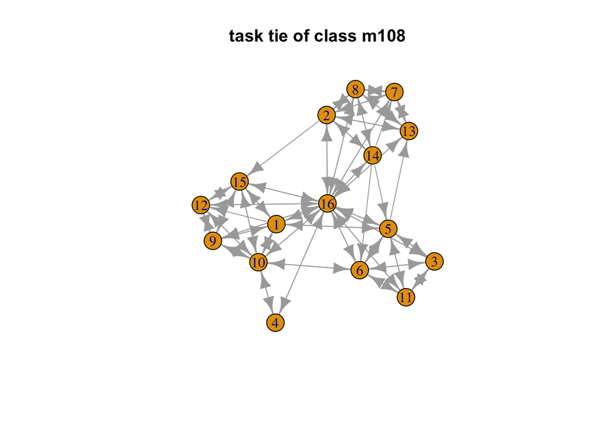

```r
g3 = graph.data.frame (t, directed=T, nodes)
plot(g3, main="task tie of class m108")
```

# 2. 計算網絡指標: centrality

## 2.1 friendship tie

```r
g=g1
degree(g)
```

```
##  1  2  3  4  5  6  7  8  9 10 11 12 13 14 15 16
##  8  9 10  0 10 10  9 11  8  8  8  8  7  9  9  0
```

```r
closeness(g)
```

```
##           1           2           3           4           5           6
## 0.004166667 0.017543860 0.018518519 0.004166667 0.019230769 0.019607843
##           7           8           9          10          11          12
## 0.017241379 0.019230769 0.017857143 0.016393443 0.018181818 0.016129032
##          13          14          15          16
## 0.017241379 0.018181818 0.017543860 0.004166667
```

```r
betweenness(g)
```

```
##          1          2          3          4          5          6          7
##  0.0000000  4.0333333 24.6000000  0.0000000 14.1833333  5.1500000 17.5666667
##          8          9         10         11         12         13         14
## 20.6000000 14.7000000  4.6666667  0.7833333  4.3666667  0.0000000 14.9000000
##         15         16
## 17.4500000  0.0000000
```

```r
eigen_centrality(g)$vector
```

```
##         1         2         3         4         5         6         7         8
## 0.6767268 0.8232318 0.9176765 0.0000000 0.9419941 0.8946166 0.8328646 1.0000000
##         9        10        11        12        13        14        15        16
## 0.6305769 0.6574638 0.7601974 0.6459215 0.6845153 0.8493349 0.7374189 0.0000000
```

```r
authority_score(g)$vector
```

```
##         1         2         3         4         5         6         7         8
## 1.0000000 0.3488410 0.6946463 0.0000000 0.5254775 0.3759995 0.5976469 0.5014374
##         9        10        11        12        13        14        15        16
## 0.2761090 0.6056958 0.4281099 0.6164605 0.2989935 0.4739182 0.5251046 0.0000000
```

```r
hub_score(g)$vector
```

```
##         1         2         3         4         5         6         7         8
## 0.0000000 0.6427870 0.5211706 0.0000000 0.8070410 1.0000000 0.3632893 0.6199550
##         9        10        11        12        13        14        15        16
## 0.7703399 0.5411043 0.7166053 0.4031331 0.4301315 0.4837438 0.5573402 0.0000000
```

## 2.2 social tie

```r
g=g2
degree(g)
```

```
##  1  2  3  4  5  6  7  8  9 10 11 12 13 14 15 16
## 17 14 15  3 16 15 14 19 10 22 17 18 16 18 18 26
```

```r
closeness(g)
```

```
##          1          2          3          4          5          6          7
## 0.04761905 0.04347826 0.04347826 0.03030303 0.04545455 0.04347826 0.04347826
##          8          9         10         11         12         13         14
## 0.04761905 0.04000000 0.05263158 0.04545455 0.04761905 0.04545455 0.04761905
##         15         16
## 0.04761905 0.06666667
```

```r
betweenness(g)
```

```
##         1         2         3         4         5         6         7         8
##  4.904762  2.252381  5.495238  0.000000  4.533333  3.064286  2.492857  7.226190
##         9        10        11        12        13        14        15        16
##  0.000000 29.026190  4.104762  8.516667  4.702381  6.961905  7.788095 23.930952
```

```r
eigen_centrality(g)$vector
```

```
##         1         2         3         4         5         6         7         8
## 0.7228696 0.5947255 0.6177062 0.1539759 0.6887434 0.6499642 0.5958392 0.7750947
##         9        10        11        12        13        14        15        16
## 0.4670912 0.8381245 0.7256737 0.7437307 0.6766520 0.7594290 0.7545228 1.0000000
```

```r
authority_score(g)$vector
```

```
##         1         2         3         4         5         6         7         8
## 0.7863135 0.6887563 0.7791425 0.2643929 0.7978321 0.8158314 0.6908067 0.9427907
##         9        10        11        12        13        14        15        16
## 0.5608191 0.9581849 0.9099984 0.8697558 0.7954952 0.8720844 0.8773060 1.0000000
```

```r
hub_score(g)$vector
```

```
##          1          2          3          4          5          6          7
## 0.66429869 0.51251735 0.49995224 0.08253448 0.59625876 0.52799721 0.51299109
##          8          9         10         11         12         13         14
## 0.63994268 0.38688630 0.73504190 0.58826648 0.63351433 0.57266324 0.66080475
##         15         16
## 0.64744346 1.00000000
```

## 2.3 task tie

```r
g=g3
degree(g)
```

```
##  1  2  3  4  5  6  7  8  9 10 11 12 13 14 15 16
## 11 11  8  4 12 11  9 10 10 14  8  9  9  9 11 30
```

```r
closeness(g)
```

```
##          1          2          3          4          5          6          7
## 0.04166667 0.04166667 0.03846154 0.03571429 0.04166667 0.04000000 0.03846154
##          8          9         10         11         12         13         14
## 0.04000000 0.04000000 0.04347826 0.03846154 0.03846154 0.03846154 0.04166667
##         15         16
## 0.04000000 0.06666667
```

```r
betweenness(g)
```

```
##           1           2           3           4           5           6
##   3.1666667   2.8666667   0.0000000   0.0000000   6.0333333   3.8333333
##           7           8           9          10          11          12
##   0.2000000   0.8666667   0.2500000   8.9166667   0.0000000   0.0000000
##          13          14          15          16
##   1.5000000   2.0000000   2.2500000 120.1166667
```

```r
eigen_centrality(g)$vector
```

```
##         1         2         3         4         5         6         7         8
## 0.5061715 0.4400390 0.3605726 0.2449343 0.4816243 0.4636842 0.3796884 0.4062126
##         9        10        11        12        13        14        15        16
## 0.4705445 0.5663678 0.3605726 0.4363208 0.3857282 0.3922954 0.5002967 1.0000000
```

```r
authority_score(g)$vector
```

```
##         1         2         3         4         5         6         7         8
## 0.4651762 0.4045518 0.3548667 0.2450722 0.5013488 0.5138736 0.4251881 0.4179528
##         9        10        11        12        13        14        15        16
## 0.4638803 0.5520274 0.3548667 0.4754106 0.4214024 0.2919008 0.5406477 1.0000000
```

```r
hub_score(g)$vector
```

```
##         1         2         3         4         5         6         7         8
## 0.5496614 0.4818002 0.3687038 0.2414417 0.4838371 0.4298441 0.3490742 0.3956094
##         9        10        11        12        13        14        15        16
## 0.4718705 0.5762235 0.3687038 0.3977115 0.3496631 0.5075966 0.4599281 1.0000000
```

# 3. 計算網絡指標: subgroups

```r
#install.packages("BiocManager")
#BiocManager::install("RBGL")
library(RBGL)
```

## 3.1 friendship tie

```r
g4=as.undirected(g1)
# k-clique in a graph is a subgraph where the distance between any two nodes is no greater than k.
cl <- kCliques(igraph.to.graphNEL(g4))
cl
```

```
## $`1-cliques`
## $`1-cliques`[[1]]
## [1] "1" "2"
##
## $`1-cliques`[[2]]
## [1] "1"  "5"  "6"  "10" "11"
##
## $`1-cliques`[[3]]
## [1] "1"  "9"  "10" "12" "15"
##
## $`1-cliques`[[4]]
## [1] "1"  "6"  "10" "12"
##
## $`1-cliques`[[5]]
## [1] "2"  "7"  "8"  "13" "14"
##
## $`1-cliques`[[6]]
## [1] "3"  "5"  "6"  "11"
##
## $`1-cliques`[[7]]
## [1] "3"  "9"  "15"
##
## $`1-cliques`[[8]]
## [1] "3"  "14"
##
## $`1-cliques`[[9]]
## [1] "5" "8"
##
## $`1-cliques`[[10]]
## [1] "6" "7"
##
## $`1-cliques`[[11]]
## [1] "7"  "8"  "15"
##
## $`1-cliques`[[12]]
## [1] "12" "14"
##
##
## $`2-cliques`
## $`2-cliques`[[1]]
##  [1] "1"  "2"  "3"  "5"  "6"  "7"  "8"  "9"  "10" "11" "12" "14" "15"
##
## $`2-cliques`[[2]]
##  [1] "1"  "2"  "3"  "5"  "6"  "7"  "8"  "12" "13" "14" "15"
##
##
## $`3-cliques`
## $`3-cliques`[[1]]
##  [1] "1"  "2"  "3"  "5"  "6"  "7"  "8"  "9"  "10" "11" "12" "13" "14" "15"
```

```r
# k-core
coreness(g4)
```

```
##  1  2  3  4  5  6  7  8  9 10 11 12 13 14 15 16
##  5  4  5  0  5  5  4  4  5  5  5  5  4  4  5  0
```

## 3.2 social tie

```r
g4=as.undirected(g2)
# k-clique in a graph is a subgraph where the distance between any two nodes is no greater than k.
cl <- kCliques(igraph.to.graphNEL(g4))
cl
```

```
## $`1-cliques`
## $`1-cliques`[[1]]
## [1] "1"  "5"  "10" "11" "15" "16"
##
## $`1-cliques`[[2]]
## [1] "1"  "8"  "11" "15" "16"
##
## $`1-cliques`[[3]]
## [1] "1"  "9"  "10" "12" "15" "16"
##
## $`1-cliques`[[4]]
## [1] "1"  "5"  "13" "16"
##
## $`1-cliques`[[5]]
## [1] "2"  "3"  "7"  "8"  "16"
##
## $`1-cliques`[[6]]
## [1] "2"  "12" "13" "14" "16"
##
## $`1-cliques`[[7]]
## [1] "2"  "7"  "8"  "13" "14" "16"
##
## $`1-cliques`[[8]]
## [1] "3"  "5"  "6"  "10" "11" "16"
##
## $`1-cliques`[[9]]
## [1] "4"  "10" "16"
##
## $`1-cliques`[[10]]
## [1] "3"  "6"  "8"  "11" "16"
##
## $`1-cliques`[[11]]
## [1] "6"  "10" "12" "14" "16"
##
## $`1-cliques`[[12]]
## [1] "6"  "8"  "11" "14" "16"
##
## $`1-cliques`[[13]]
## [1] "7"  "8"  "15" "16"
##
## $`1-cliques`[[14]]
## [1] "1"  "8"  "13" "16"
##
## $`1-cliques`[[15]]
## [1] "6"  "10" "11" "14" "16"
##
## $`1-cliques`[[16]]
## [1] "1"  "12" "13" "16"
##
##
## $`2-cliques`
## $`2-cliques`[[1]]
##  [1] "1"  "2"  "3"  "4"  "5"  "6"  "7"  "8"  "9"  "10" "11" "12" "13" "14" "15"
## [16] "16"
```

```r
# k-core
coreness(g4)
```

```
##  1  2  3  4  5  6  7  8  9 10 11 12 13 14 15 16
##  7  7  7  2  7  7  7  7  5  7  7  7  7  7  7  7
```

## 3.3 task tie

```r
g4=as.undirected(g3)
# k-clique in a graph is a subgraph where the distance between any two nodes is no greater than k.
cl <- kCliques(igraph.to.graphNEL(g4))
cl
```

```
## $`1-cliques`
## $`1-cliques`[[1]]
## [1] "1"  "5"  "16"
##
## $`1-cliques`[[2]]
## [1] "1"  "9"  "10" "12" "15" "16"
##
## $`1-cliques`[[3]]
## [1] "2"  "7"  "8"  "13" "16"
##
## $`1-cliques`[[4]]
## [1] "2"  "7"  "8"  "14" "16"
##
## $`1-cliques`[[5]]
## [1] "2"  "15" "16"
##
## $`1-cliques`[[6]]
## [1] "3"  "5"  "6"  "11" "16"
##
## $`1-cliques`[[7]]
## [1] "4"  "10" "16"
##
## $`1-cliques`[[8]]
## [1] "5"  "13" "16"
##
## $`1-cliques`[[9]]
## [1] "5"  "6"  "14" "16"
##
## $`1-cliques`[[10]]
## [1] "6"  "10" "16"
##
##
## $`2-cliques`
## $`2-cliques`[[1]]
##  [1] "1"  "2"  "3"  "4"  "5"  "6"  "7"  "8"  "9"  "10" "11" "12" "13" "14" "15"
## [16] "16"
```

```r
# k-core
coreness(g4)
```

```
##  1  2  3  4  5  6  7  8  9 10 11 12 13 14 15 16
##  5  4  4  2  4  4  4  4  5  5  4  5  4  4  5  5
```

# 4. Conclusion

## 討論friendship, social and task這三種關係，m108班級成員重疊性與成員的網絡連結特性。從繪圖當中可以看到，班上一共有16為學生，而在friendship 的連結上，4號同學以及16號同學沒有與任何其他人有連結，為孤立的節點，可以推測為並無與班上其他同學建立友誼，是班級邊緣人。 然而，在social以及task的關係中，就班級所有16個人都有連結。

## 從Centrality 指標的角度來看，若比較degree，班級上連結的中心強度，綜觀全班的網絡，最強的是social，再來是task，最弱是friendship。其中很特別的是，16號同學，social跟task的中心性都最強，但是friendship＝0，這樣的同學，可能就是在網絡當中，不講究情感需求，是任務以及社交工具論導向。

## 從Sub groups 指標的角度來看，綜觀全班的網絡，小圈圈最大的是的是social，再來是task，最弱是friendship，有一些小圈圈有0人，也就是完全沒朋友，出現在friendship，而班上有幾位朋友王，他們的小區圈圈則有5為朋友。社交取向的小圈圈最多有7人，任務取向的小圈圈最多有5人。

# 5.Raw data

```r
m182_full_data_frame
```

[output not shown]

[output cut: 242 more lines]